# student_performance

Connected to Python 3.14.8

```python
import json
from pathlib import Path

import joblib
import matplotlib.pyplot as plt
import numpy as np
import pandas as pd
import seaborn as sns
from sklearn.compose import ColumnTransformer
from sklearn.ensemble import GradientBoostingRegressor, RandomForestClassifier, RandomForestRegressor
from sklearn.impute import SimpleImputer
from sklearn.inspection import permutation_importance
from sklearn.linear_model import LinearRegression, LogisticRegression, Ridge
from sklearn.metrics import (
    ConfusionMatrixDisplay,
    accuracy_score,
    classification_report,
    f1_score,
    mean_absolute_error,
    mean_squared_error,
    precision_score,
    r2_score,
    recall_score,
)
from sklearn.model_selection import cross_val_score, train_test_split
from sklearn.pipeline import Pipeline
from sklearn.preprocessing import OneHotEncoder, StandardScaler
from sklearn.tree import DecisionTreeClassifier

try:
    BASE_DIR = Path(__file__).resolve().parent
except NameError:
    BASE_DIR = Path.cwd()
    if BASE_DIR.name == "notebooks":
        BASE_DIR = BASE_DIR.parent

DATA_PATH = BASE_DIR / "datasets" / "student_performance.csv"
MODEL_DIR = BASE_DIR / "models"
OUT_DIR = BASE_DIR / "outputs"
MODEL_DIR.mkdir(exist_ok=True)
OUT_DIR.mkdir(exist_ok=True)

pd.set_option("display.width", 200)          # show wide tables fully
pd.set_option("display.max_columns", 20)

RANDOM_STATE = 42
NUMERIC_COLUMNS = ["attendance_pct", "internal_marks", "assignment_score",
                   "study_hours_per_day", "previous_sem_result"]
CATEGORICAL_COLUMNS = ["extra_classes"]
FEATURE_COLUMNS = NUMERIC_COLUMNS + CATEGORICAL_COLUMNS
TARGET_REGRESSION = "final_marks"
LEVEL_NAMES = ["At Risk", "Average", "Excellent"]     # classes for classification


def save_and_show(file_name):
    """Save the current figure into the outputs folder and display it."""
    plt.savefig(OUT_DIR / file_name, dpi=120, bbox_inches="tight")
    plt.show()
```

## Step 2: Load the dataset

```python
try:
    if not DATA_PATH.exists():
        raise FileNotFoundError(f"Dataset not found: {DATA_PATH}")
    raw_df = pd.read_csv(DATA_PATH)
except (FileNotFoundError, pd.errors.ParserError) as err:
    print("Error while loading dataset:", err)
    raise

print("Shape:", raw_df.shape)
print(raw_df.head())
```

```
Shape: (506, 8)
   student_id  attendance_pct  internal_marks  assignment_score  study_hours_per_day  previous_sem_result extra_classes  final_marks
0        2001            71.2            17.7               7.4                  3.0                 52.5            No         55.8
1        2002            73.6            11.0               7.5                  3.6                 51.2           Yes         49.8
2        2003            75.4            11.7              10.5                  3.7                 64.0           Yes         68.8
3        2004            94.9            20.3              14.9                  4.8                 54.5           NaN         69.0
4        2005             NaN            26.9              14.7                  4.7                 76.7           Yes         76.9
```

## Step 3: Explore the data (EDA)

We look at the data types, summary statistics, missing values and duplicates.

```python
raw_df.info()
print("\nSummary statistics:\n", raw_df.describe().round(2))
print("\nMissing values:\n", raw_df.isnull().sum())
print("\nDuplicate rows:", raw_df.duplicated().sum())
```

```
<class 'pandas.DataFrame'>
RangeIndex: 506 entries, 0 to 505
Data columns (total 8 columns):
 #   Column               Non-Null Count  Dtype
---  ------               --------------  -----
 0   student_id           506 non-null    int64
 1   attendance_pct       487 non-null    float64
 2   internal_marks       506 non-null    float64
 3   assignment_score     494 non-null    float64
 4   study_hours_per_day  491 non-null    float64
 5   previous_sem_result  506 non-null    float64
 6   extra_classes        496 non-null    str
 7   final_marks          506 non-null    float64
dtypes: float64(6), int64(1), str(1)
memory usage: 31.8 KB

Summary statistics:
        student_id  attendance_pct  internal_marks  assignment_score  study_hours_per_day  previous_sem_result  final_marks
count      506.00          487.00          506.00            494.00               491.00               506.00       506.00
mean      2251.25           76.30           18.02             12.13                 3.56                65.05        66.88
std        144.29           10.14            5.10              3.85                 1.50                10.90        11.18
min       2001.00           40.00            0.00              0.00                 0.50                35.00        24.00
25%       2127.25           69.85           14.62              9.40                 2.60                57.32        59.82
50%       2251.50           76.60           17.70             11.90                 3.60                65.90        66.80
75%       2376.75           83.55           21.60             14.70                 4.50                71.88        75.18
max       2500.00          100.00           30.00             20.00                 7.40                94.20        94.30

Missing values:
 student_id              0
attendance_pct         19
internal_marks          0
assignment_score       12
study_hours_per_day    15
previous_sem_result     0
extra_classes          10
final_marks             0
dtype: int64

Duplicate rows: 6
```

```python
clean_df = raw_df.drop_duplicates().reset_index(drop=True)
print("Rows after removing duplicates:", len(clean_df))

valid_ranges = {"attendance_pct": (0, 100), "internal_marks": (0, 30), "assignment_score": (0, 20),
                "study_hours_per_day": (0, 24), "previous_sem_result": (0, 100), "final_marks": (0, 100)}
for column, (low, high) in valid_ranges.items():
    outside = ((clean_df[column] < low) | (clean_df[column] > high)).sum()
    print(f"{column}: {outside} values outside {low}-{high}")

# Create the classification target from the final marks
clean_df["performance_level"] = pd.cut(
    clean_df[TARGET_REGRESSION], bins=[-np.inf, 45, 70, np.inf], labels=LEVEL_NAMES)
print("\nStudents in each performance level:")
print(clean_df["performance_level"].value_counts().reindex(LEVEL_NAMES))
```

```
Rows after removing duplicates: 500
attendance_pct: 0 values outside 0-100
internal_marks: 0 values outside 0-30
assignment_score: 0 values outside 0-20
study_hours_per_day: 0 values outside 0-24
previous_sem_result: 0 values outside 0-100
final_marks: 0 values outside 0-100

Students in each performance level:
performance_level
At Risk       16
Average      291
Excellent    193
Name: count, dtype: int64
```

## Step 5: Visualize the data

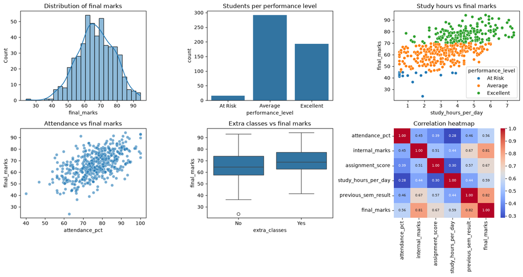

```python
fig, axes = plt.subplots(2, 3, figsize=(15, 8))
sns.histplot(clean_df[TARGET_REGRESSION], bins=25, kde=True, ax=axes[0, 0])
axes[0, 0].set_title("Distribution of final marks")
sns.countplot(x="performance_level", data=clean_df, order=LEVEL_NAMES, ax=axes[0, 1])
axes[0, 1].set_title("Students per performance level")
sns.scatterplot(x="study_hours_per_day", y=TARGET_REGRESSION, hue="performance_level",
                hue_order=LEVEL_NAMES, data=clean_df, ax=axes[0, 2])
axes[0, 2].set_title("Study hours vs final marks")
sns.scatterplot(x="attendance_pct", y=TARGET_REGRESSION, data=clean_df, ax=axes[1, 0], alpha=0.6)
axes[1, 0].set_title("Attendance vs final marks")
sns.boxplot(x="extra_classes", y=TARGET_REGRESSION, data=clean_df, ax=axes[1, 1])
axes[1, 1].set_title("Extra classes vs final marks")
sns.heatmap(clean_df[NUMERIC_COLUMNS + [TARGET_REGRESSION]].corr(), annot=True, fmt=".2f",
            cmap="coolwarm", ax=axes[1, 2], annot_kws={"size": 7})
axes[1, 2].set_title("Correlation heatmap")
plt.tight_layout()
save_and_show("p1_eda.png")
```

## Step 6: Split into training and testing sets

80% of the students train the model, 20% are kept hidden to test it. For classification we use `stratify` so each level has the same share in both sets.

```python
X = clean_df[FEATURE_COLUMNS]
y_marks = clean_df[TARGET_REGRESSION]
y_level = clean_df["performance_level"].astype(str)

X_train, X_test, y_marks_train, y_marks_test, y_level_train, y_level_test = train_test_split(
    X, y_marks, y_level, test_size=0.2, random_state=RANDOM_STATE, stratify=y_level)
print("Training students:", len(X_train), "| Testing students:", len(X_test))
```

```
Training students: 400 | Testing students: 100
```

## Step 7: Preprocessing pipeline

- Numeric columns: fill missing values with the **median**, then **standardize**.
- Category column (`extra_classes`): fill missing values with the **most common** value, then **one-hot encode**.

The pipeline learns these values from the training data only.

```python
numeric_pipeline = Pipeline([("fill_missing", SimpleImputer(strategy="median")),
                             ("scale", StandardScaler())])
categorical_pipeline = Pipeline([("fill_missing", SimpleImputer(strategy="most_frequent")),
                                 ("encode", OneHotEncoder(handle_unknown="ignore"))])
preprocessor = ColumnTransformer([("numeric", numeric_pipeline, NUMERIC_COLUMNS),
                                  ("categorical", categorical_pipeline, CATEGORICAL_COLUMNS)])
print(preprocessor)
```

```
ColumnTransformer(transformers=[('numeric',
                                 Pipeline(steps=[('fill_missing',
                                                  SimpleImputer(strategy='median')),
                                                 ('scale', StandardScaler())]),
                                 ['attendance_pct', 'internal_marks',
                                  'assignment_score', 'study_hours_per_day',
                                  'previous_sem_result']),
                                ('categorical',
                                 Pipeline(steps=[('fill_missing',
                                                  SimpleImputer(strategy='most_frequent')),
                                                 ('encode',
                                                  OneHotEncoder(handle_unknown='ignore'))]),
                                 ['extra_classes'])])
```

# Part A: Regression (predict the final marks)

## Step 8: Compare regression algorithms

```python
regression_models = {
    "Linear Regression": LinearRegression(),
    "Ridge Regression": Ridge(alpha=1.0),
    "Random Forest": RandomForestRegressor(n_estimators=200, random_state=RANDOM_STATE),
    "Gradient Boosting": GradientBoostingRegressor(random_state=RANDOM_STATE),
}

regression_pipelines, regression_rows = {}, []
for name, model in regression_models.items():
    pipeline = Pipeline([("preprocess", preprocessor), ("model", model)])
    pipeline.fit(X_train, y_marks_train)
    predictions = pipeline.predict(X_test)
    cv_r2 = cross_val_score(pipeline, X_train, y_marks_train, cv=5, scoring="r2")
    mse = mean_squared_error(y_marks_test, predictions)
    regression_pipelines[name] = pipeline
    regression_rows.append({
        "Model": name,
        "MAE": mean_absolute_error(y_marks_test, predictions),
        "MSE": mse,
        "RMSE": np.sqrt(mse),
        "R2 (test)": r2_score(y_marks_test, predictions),
        "R2 (5-fold CV)": cv_r2.mean(),
    })

regression_table = pd.DataFrame(regression_rows).set_index("Model").round(4)
print(regression_table.sort_values("R2 (test)", ascending=False))

best_regression_name = regression_table["R2 (test)"].idxmax()
best_regression = regression_pipelines[best_regression_name]
print("\nBest regression model:", best_regression_name)
```

```
                      MAE      MSE    RMSE  R2 (test)  R2 (5-fold CV)
Model
Linear Regression  2.9536  13.8049  3.7155     0.8994          0.8547
Ridge Regression   2.9547  13.8051  3.7155     0.8994          0.8547
Gradient Boosting  3.2080  18.1785  4.2636     0.8675          0.8080
Random Forest      3.5840  21.3845  4.6243     0.8441          0.8086

Best regression model: Linear Regression
```

## Step 9: Interpret the regression metrics

- **MAE**: the average mistake in marks.
- **RMSE**: like MAE but punishes big mistakes more. Same unit as marks.
- **R2**: share of the variation in marks that the model explains (1 = perfect).
- **CV R2** close to **test R2** means the model is not just lucky on one split.

```python
best_row = regression_table.loc[best_regression_name]
print(f"{best_regression_name}: on average the predicted marks are about "
      f"{best_row['MAE']:.1f} marks away from the real marks (MAE).")
print(f"The typical error (RMSE) is {best_row['RMSE']:.1f} marks.")
print(f"The model explains {best_row['R2 (test)'] * 100:.1f}% of the differences between students (R2).")
```

```
Linear Regression: on average the predicted marks are about 3.0 marks away from the real marks (MAE).
The typical error (RMSE) is 3.7 marks.
The model explains 89.9% of the differences between students (R2).
```

## Step 10: Visualize the regression results

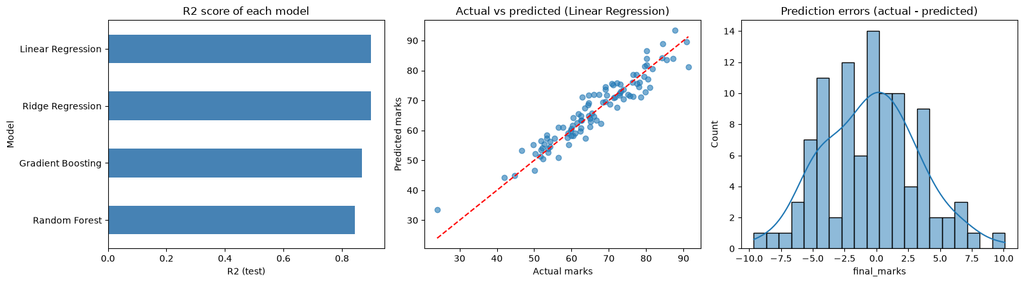

```python
best_predictions = best_regression.predict(X_test)
residuals = y_marks_test - best_predictions

fig, axes = plt.subplots(1, 3, figsize=(16, 4.5))
regression_table["R2 (test)"].sort_values().plot.barh(ax=axes[0], color="steelblue")
axes[0].set_title("R2 score of each model")
axes[0].set_xlabel("R2 (test)")

axes[1].scatter(y_marks_test, best_predictions, alpha=0.6)
axes[1].plot([y_marks_test.min(), y_marks_test.max()], [y_marks_test.min(), y_marks_test.max()], "r--")
axes[1].set_title(f"Actual vs predicted ({best_regression_name})")
axes[1].set_xlabel("Actual marks")
axes[1].set_ylabel("Predicted marks")

sns.histplot(residuals, bins=20, kde=True, ax=axes[2])
axes[2].set_title("Prediction errors (actual - predicted)")
plt.tight_layout()
save_and_show("p1_regression_results.png")
```

## Step 11: Which factors matter most?

Permutation importance: shuffle one column and see how much the score drops.

```
internal_marks         0.2652
previous_sem_result    0.2213
assignment_score       0.0744
study_hours_per_day    0.0580
attendance_pct         0.0234
extra_classes          0.0157
dtype: float64
```

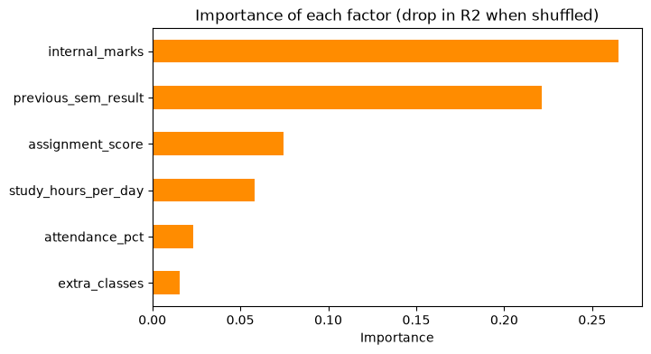

```python
importance = permutation_importance(best_regression, X_test, y_marks_test, n_repeats=15,
                                    random_state=RANDOM_STATE, scoring="r2")
importance_series = pd.Series(importance.importances_mean, index=FEATURE_COLUMNS).sort_values()
print(importance_series.round(4).sort_values(ascending=False))

plt.figure(figsize=(7, 4))
importance_series.plot.barh(color="darkorange")
plt.title("Importance of each factor (drop in R2 when shuffled)")
plt.xlabel("Importance")
save_and_show("p1_feature_importance.png")
```

# Part B: Classification (predict the performance level)

## Step 12: Compare classification algorithms

```python
classification_models = {
    "Logistic Regression": LogisticRegression(max_iter=1000),
    "Decision Tree": DecisionTreeClassifier(max_depth=5, random_state=RANDOM_STATE),
    "Random Forest": RandomForestClassifier(n_estimators=200, random_state=RANDOM_STATE),
}

classification_pipelines, classification_rows = {}, []
for name, model in classification_models.items():
    pipeline = Pipeline([("preprocess", preprocessor), ("model", model)])
    pipeline.fit(X_train, y_level_train)
    predictions = pipeline.predict(X_test)
    cv_accuracy = cross_val_score(pipeline, X_train, y_level_train, cv=5, scoring="accuracy")
    classification_pipelines[name] = pipeline
    classification_rows.append({
        "Model": name,
        "Accuracy": accuracy_score(y_level_test, predictions),
        "Precision": precision_score(y_level_test, predictions, average="weighted", zero_division=0),
        "Recall": recall_score(y_level_test, predictions, average="weighted", zero_division=0),
        "F1-score": f1_score(y_level_test, predictions, average="weighted", zero_division=0),
        "Accuracy (5-fold CV)": cv_accuracy.mean(),
    })

classification_table = pd.DataFrame(classification_rows).set_index("Model").round(4)
print(classification_table.sort_values("Accuracy", ascending=False))

best_classifier_name = classification_table["Accuracy"].idxmax()
best_classifier = classification_pipelines[best_classifier_name]
print("\nBest classification model:", best_classifier_name)
```

```
                     Accuracy  Precision  Recall  F1-score  Accuracy (5-fold CV)
Model
Logistic Regression      0.88     0.8845    0.88    0.8806                0.8700
Random Forest            0.87     0.8696    0.87    0.8697                0.8675
Decision Tree            0.79     0.8053    0.79    0.7937                0.8000

Best classification model: Logistic Regression
```

## Step 13: Evaluate the best classifier

- **Accuracy**: share of students put in the correct level.
- **Precision**: of the students predicted as a level, how many really are in it.
- **Recall**: of the students really in a level, how many the model found.
- The **confusion matrix** shows which levels get mixed up.

```
              precision    recall  f1-score   support

     At Risk       0.75      1.00      0.86         3
     Average       0.93      0.86      0.89        58
   Excellent       0.83      0.90      0.86        39

    accuracy                           0.88       100
   macro avg       0.84      0.92      0.87       100
weighted avg       0.88      0.88      0.88       100
```

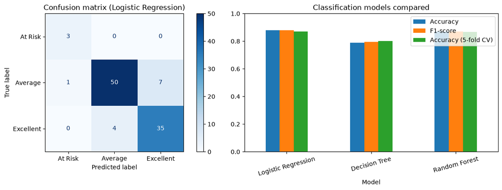

```
The model finds 100% of the students who are really 'At Risk'.
(For a teacher, catching At Risk students early is the most useful result.)
```

```python
best_classifier_predictions = best_classifier.predict(X_test)
print(classification_report(y_level_test, best_classifier_predictions, labels=LEVEL_NAMES, zero_division=0))

fig, axes = plt.subplots(1, 2, figsize=(13, 4.5))
ConfusionMatrixDisplay.from_predictions(y_level_test, best_classifier_predictions,
                                        labels=LEVEL_NAMES, cmap="Blues", ax=axes[0])
axes[0].set_title(f"Confusion matrix ({best_classifier_name})")
classification_table[["Accuracy", "F1-score", "Accuracy (5-fold CV)"]].plot.bar(ax=axes[1])
axes[1].set_title("Classification models compared")
axes[1].set_ylim(0, 1)
axes[1].tick_params(axis="x", rotation=15)
plt.tight_layout()
save_and_show("p1_classification_results.png")

at_risk_recall = recall_score(y_level_test, best_classifier_predictions, labels=["At Risk"],
                              average=None, zero_division=0)[0]
print(f"The model finds {at_risk_recall:.0%} of the students who are really 'At Risk'.")
print("(For a teacher, catching At Risk students early is the most useful result.)")
```

## Step 14: Save the trained models

```python
try:
    joblib.dump(best_regression, MODEL_DIR / "student_marks_model.joblib")
    joblib.dump(best_classifier, MODEL_DIR / "student_level_model.joblib")
    model_info = {
        "regression_model": best_regression_name,
        "regression_metrics": regression_table.loc[best_regression_name].to_dict(),
        "classification_model": best_classifier_name,
        "classification_metrics": classification_table.loc[best_classifier_name].to_dict(),
        "feature_columns": FEATURE_COLUMNS,
        "levels": LEVEL_NAMES,
    }
    with open(MODEL_DIR / "model_info.json", "w", encoding="utf-8") as info_file:
        json.dump(model_info, info_file, indent=2)
    print("Saved in the models folder:")
    for saved_file in sorted(MODEL_DIR.glob("*")):
        print(" -", saved_file.name)
except OSError as err:
    print("Could not save model:", err)
```

```
Saved in the models folder:
 - .gitkeep
 - model_info.json
 - student_level_model.joblib
 - student_marks_model.joblib
```

## Step 15: Load the saved models and predict for new students

```python
marks_model = joblib.load(MODEL_DIR / "student_marks_model.joblib")
level_model = joblib.load(MODEL_DIR / "student_level_model.joblib")

new_students = pd.DataFrame({
    "attendance_pct": [92, 70, 55],
    "internal_marks": [27, 18, 9],
    "assignment_score": [18, 12, 6],
    "study_hours_per_day": [5.0, 3.0, 1.0],
    "previous_sem_result": [88, 65, 48],
    "extra_classes": ["Yes", "No", "No"],
})
result = new_students.copy()
result["Predicted final marks"] = marks_model.predict(new_students).round(1)
result["Predicted level"] = level_model.predict(new_students)
print(result.to_string(index=False))
```

```
 attendance_pct  internal_marks  assignment_score  study_hours_per_day  previous_sem_result extra_classes  Predicted final marks Predicted level
             92              27                18                  5.0                   88           Yes                   90.3       Excellent
             70              18                12                  3.0                   65            No                   64.5         Average
             55               9                 6                  1.0                   48            No                   43.7         At Risk
```

## Conclusion

Several algorithms were compared for both regression and classification. The best models were saved with Joblib and used to predict the performance of new students. The most important factors are shown in the feature importance chart.